# Introduction to Open Data Science - Course Project

## 5.

```r
m <- glm(high_use ~ famrel + G3 + goout + failures, data = alc, family = "binomial")

# view summary
summary(m)
```

```
##
## Call:
## glm(formula = high_use ~ famrel + G3 + goout + failures, family = "binomial",
##     data = alc)
##
## Deviance Residuals:
##     Min       1Q   Median       3Q      Max
## -1.8046  -0.7672  -0.5733   0.9947   2.3416
##
## Coefficients:
##             Estimate Std. Error z value Pr(>|z|)
## (Intercept) -1.68968    0.80944  -2.087   0.0368 *
## famrel      -0.37266    0.13616  -2.737   0.0062 **
## G3          -0.02464    0.04099  -0.601   0.5478
## goout        0.75188    0.12022   6.254    4e-10 ***
## failures     0.48924    0.22963   2.131   0.0331 *
## ---
## Signif. codes:  0 '***' 0.001 '**' 0.01 '*' 0.05 '.' 0.1 ' ' 1
##
## (Dispersion parameter for binomial family taken to be 1)
##
##     Null deviance: 452.04  on 369  degrees of freedom
## Residual deviance: 388.05  on 365  degrees of freedom
## AIC: 398.05
##
## Number of Fisher Scoring iterations: 4
```

Going out is the strongest predictor of high alcohol use (p < .001). Family relations also have a significance level of < .01. Failures are significant at p < .05.

Final grade does not have a significant correlation with high use.

In terms of my hypotheses, famrel, goout and failures are supported. G3 is not.

```r
# compute odds ratios (OR)
OR <- coef(m) %>% exp

# compute confidence intervals (CI)
CI <- confint(m) %>% exp
# print out the odds ratios with their confidence intervals
cbind(OR, CI)
```

```
##                    OR      2.5 %    97.5 %
## (Intercept) 0.1845781 0.03639237 0.8771040
## famrel      0.6888964 0.52587985 0.8985892
## G3          0.9756601 0.90036973 1.0578228
## goout       2.1209922 1.68623053 2.7043570
## failures    1.6310777 1.04644221 2.5883902
```

The odds ratio here is the change in the odds of high/low alcohol use.

# Clustering and classification

```r
date()
```

```
## [1] "Tue Dec 13 02:32:47 2022"
```

```r
#library(GGally)
#library(dplyr)
library(MASS)
library(tidyr)
library(corrplot)
library(ggplot2)
data("Boston")
```

## 2.

The data set describes housing value in suburbs of Boston, Massachusetts. The data set has been put together and analyzed by Harrison & Rubinfeld (1978). The raw data has been collected in ~1970 (Harrison & Rubinfeld, 1978).

Listing of its variables are available [here](https://stat.ethz.ch/R-manual/R-devel/library/MASS/html/Boston.html), for instance. Definitions of how the variables have been collected and calculated can be found in Harrison, D. and Rubinfeld, D.L. (1978) Hedonic prices and the demand for clean air. J. Environ. Economics and Management 5, 81–102.

```r
str(Boston)
```

```
## 'data.frame':	506 obs. of  14 variables:
##  $ crim   : num  0.00632 0.02731 0.02729 0.03237 0.06905 ...
##  $ zn     : num  18 0 0 0 0 0 12.5 12.5 12.5 12.5 ...
##  $ indus  : num  2.31 7.07 7.07 2.18 2.18 2.18 7.87 7.87 7.87 7.87 ...
##  $ chas   : int  0 0 0 0 0 0 0 0 0 0 ...
##  $ nox    : num  0.538 0.469 0.469 0.458 0.458 0.458 0.524 0.524 0.524 0.524 ...
##  $ rm     : num  6.58 6.42 7.18 7 7.15 ...
##  $ age    : num  65.2 78.9 61.1 45.8 54.2 58.7 66.6 96.1 100 85.9 ...
##  $ dis    : num  4.09 4.97 4.97 6.06 6.06 ...
##  $ rad    : int  1 2 2 3 3 3 5 5 5 5 ...
##  $ tax    : num  296 242 242 222 222 222 311 311 311 311 ...
##  $ ptratio: num  15.3 17.8 17.8 18.7 18.7 18.7 15.2 15.2 15.2 15.2 ...
##  $ black  : num  397 397 393 395 397 ...
##  $ lstat  : num  4.98 9.14 4.03 2.94 5.33 ...
##  $ medv   : num  24 21.6 34.7 33.4 36.2 28.7 22.9 27.1 16.5 18.9 ...
```

There are 506 observations and 14 variables. Each observation represents one neighborhood/town.

In summary, the variables include median values of homes, variables describing housing, infrastructural, environmental and industrial structure, and demographic information on the neighborhood (Harrison & Rubinfeld, 1978).

```r
summary(Boston)
```

```
##       crim                zn             indus            chas              nox
##  Min.   : 0.00632   Min.   :  0.00   Min.   : 0.46   Min.   :0.00000   Min.   :0.3850
##  1st Qu.: 0.08205   1st Qu.:  0.00   1st Qu.: 5.19   1st Qu.:0.00000   1st Qu.:0.4490
##  Median : 0.25651   Median :  0.00   Median : 9.69   Median :0.00000   Median :0.5380
##  Mean   : 3.61352   Mean   : 11.36   Mean   :11.14   Mean   :0.06917   Mean   :0.5547
##  3rd Qu.: 3.67708   3rd Qu.: 12.50   3rd Qu.:18.10   3rd Qu.:0.00000   3rd Qu.:0.6240
##  Max.   :88.97620   Max.   :100.00   Max.   :27.74   Max.   :1.00000   Max.   :0.8710
##        rm             age              dis              rad              tax
##  Min.   :3.561   Min.   :  2.90   Min.   : 1.130   Min.   : 1.000   Min.   :187.0
##  1st Qu.:5.886   1st Qu.: 45.02   1st Qu.: 2.100   1st Qu.: 4.000   1st Qu.:279.0
##  Median :6.208   Median : 77.50   Median : 3.207   Median : 5.000   Median :330.0
##  Mean   :6.285   Mean   : 68.57   Mean   : 3.795   Mean   : 9.549   Mean   :408.2
##  3rd Qu.:6.623   3rd Qu.: 94.08   3rd Qu.: 5.188   3rd Qu.:24.000   3rd Qu.:666.0
##  Max.   :8.780   Max.   :100.00   Max.   :12.127   Max.   :24.000   Max.   :711.0
##     ptratio          black            lstat            medv
##  Min.   :12.60   Min.   :  0.32   Min.   : 1.73   Min.   : 5.00
##  1st Qu.:17.40   1st Qu.:375.38   1st Qu.: 6.95   1st Qu.:17.02
##  Median :19.05   Median :391.44   Median :11.36   Median :21.20
##  Mean   :18.46   Mean   :356.67   Mean   :12.65   Mean   :22.53
##  3rd Qu.:20.20   3rd Qu.:396.23   3rd Qu.:16.95   3rd Qu.:25.00
##  Max.   :22.00   Max.   :396.90   Max.   :37.97   Max.   :50.00
```

The median value of housing seems to be capped at $50.000, which looks like an artificial decision.

Let’s visualize the data set.

## 3.

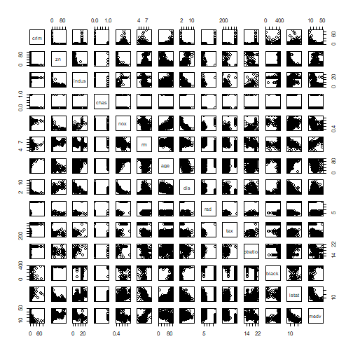

```r
# Create scatterplot matrix
pairs(Boston)
```

### Commenting on median value plotted against other factors:

Not surprisingly, higher-value areas have lower crime rates. The density of residential areas (var zn) and whether tract bounds river (chas [this is not surprising as this is a dummy variable anyway]) do not have a clear effect on housing value. Prices seem to be lower where industrial density is very high, but low industrial density has both high and low-value areas. The situation looks fairly similar with highly polluted areas (one might ask how independent nox and indus are). As average number of rooms in units (rm) grows, so does value – again, not surprisingly. Newest areas are not cheap, but the priciest areas are not new. Both the cheapest and the most expensive area seem to have a short distance to Boston employment centers. Rad – index of accessibility to radial highways – seems to have a very binary distribution despite its values varying from 1 to 24. I am not sure how to interpret how tax and value are related (the highest taxes seem to be in cheapest areas, which seems odd from someone coming from a progressive tax state). Pupil-teacher ratio is generally lower in more valuable neighborhoods, as one would expect. Towns with a lower proportion of African-Americans are not among the most expensive areas. There is a high correlation between the price of housing and lower percentage of “lower-status” population (i.e., male workers classified as laborers and adults with no high school education).

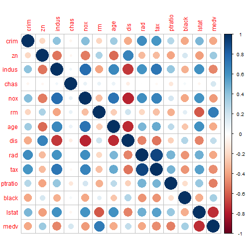

```r
# Look at correlations
corbos = cor(Boston)
corrplot(corbos)
```

The strongest correlation seems to be between radial highway accessibility and property tax rate. Looking at the scatterplot matrix, there is a highly taxed highly accessible outlier, which may confound the results. Distance and pollution have a strong negative correlation: far-away areas have lower pollution. Nox and indus are also strongly correlated.

## 4.

```r
# Standardize the dataset and print out summaries of the scaled data. How did the variables change? Create a categorical variable of the crime rate in the Boston dataset (from the scaled crime rate). Use the quantiles as the break points in the categorical variable. Drop the old crime rate variable from the dataset. Divide the dataset to train and test sets, so that 80% of the data belongs to the train set. (0-2 points)

boston_scaled <- scale(Boston)
summary(boston_scaled)
```

```
##       crim                 zn               indus              chas              nox
##  Min.   :-0.419367   Min.   :-0.48724   Min.   :-1.5563   Min.   :-0.2723   Min.   :-1.4644
##  1st Qu.:-0.410563   1st Qu.:-0.48724   1st Qu.:-0.8668   1st Qu.:-0.2723   1st Qu.:-0.9121
##  Median :-0.390280   Median :-0.48724   Median :-0.2109   Median :-0.2723   Median :-0.1441
##  Mean   : 0.000000   Mean   : 0.00000   Mean   : 0.0000   Mean   : 0.0000   Mean   : 0.0000
##  3rd Qu.: 0.007389   3rd Qu.: 0.04872   3rd Qu.: 1.0150   3rd Qu.:-0.2723   3rd Qu.: 0.5981
##  Max.   : 9.924110   Max.   : 3.80047   Max.   : 2.4202   Max.   : 3.6648   Max.   : 2.7296
##        rm               age               dis               rad               tax
##  Min.   :-3.8764   Min.   :-2.3331   Min.   :-1.2658   Min.   :-0.9819   Min.   :-1.3127
##  1st Qu.:-0.5681   1st Qu.:-0.8366   1st Qu.:-0.8049   1st Qu.:-0.6373   1st Qu.:-0.7668
##  Median :-0.1084   Median : 0.3171   Median :-0.2790   Median :-0.5225   Median :-0.4642
##  Mean   : 0.0000   Mean   : 0.0000   Mean   : 0.0000   Mean   : 0.0000   Mean   : 0.0000
##  3rd Qu.: 0.4823   3rd Qu.: 0.9059   3rd Qu.: 0.6617   3rd Qu.: 1.6596   3rd Qu.: 1.5294
##  Max.   : 3.5515   Max.   : 1.1164   Max.   : 3.9566   Max.   : 1.6596   Max.   : 1.7964
##     ptratio            black             lstat              medv
##  Min.   :-2.7047   Min.   :-3.9033   Min.   :-1.5296   Min.   :-1.9063
##  1st Qu.:-0.4876   1st Qu.: 0.2049   1st Qu.:-0.7986   1st Qu.:-0.5989
##  Median : 0.2746   Median : 0.3808   Median :-0.1811   Median :-0.1449
##  Mean   : 0.0000   Mean   : 0.0000   Mean   : 0.0000   Mean   : 0.0000
##  3rd Qu.: 0.8058   3rd Qu.: 0.4332   3rd Qu.: 0.6024   3rd Qu.: 0.2683
##  Max.   : 1.6372   Max.   : 0.4406   Max.   : 3.5453   Max.   : 2.9865
```

Columns are scaled by first subtracting column values by the corresponding column mean, and then dividing the difference by standard deviation. This way, the mean for all variables is at 0, and we can compare variables in a more meaningful way.

```r
boston_scaled<-as.data.frame(boston_scaled)
boston_scaled$crim <- as.numeric(boston_scaled$crim)
# create a quantile vector of crim and print it
bins <- quantile(boston_scaled$crim)
bins
```

```
##           0%          25%          50%          75%         100%
## -0.419366929 -0.410563278 -0.390280295  0.007389247  9.924109610
```

```r
# create a categorical variable 'crime'
crime <- cut(boston_scaled$crim, breaks = bins, include.lowest = TRUE, label=c("low","med_low","med_high","high"))

# look at the table of the new factor crime
table(crime)
```

```
## crime
##      low  med_low med_high     high
##      127      126      126      127
```

```r
# remove original crim from the dataset
boston_scaled <- dplyr::select(boston_scaled, -crim)

# add the new categorical value to scaled data
boston_scaled <- data.frame(boston_scaled, crime)

# number of rows in the Boston dataset
n <- nrow(boston_scaled)

# choose randomly 80% of the rows
ind <- sample(n,  size = n * 0.8)

# create train set
train <- boston_scaled[ind,]

# create test set
test <- boston_scaled[-ind,]
```

## 5.

```r
# Fit the linear discriminant analysis on the train set. Use the categorical crime rate as the target variable and all the other variables in the dataset as predictor variables. Draw the LDA (bi)plot. (0-3 points)

# linear discriminant analysis
lda.fit <- lda(crime ~ ., data = train)

# print the lda.fit object
lda.fit
```

```
## Call:
## lda(crime ~ ., data = train)
##
## Prior probabilities of groups:
##       low   med_low  med_high      high
## 0.2623762 0.2623762 0.2301980 0.2450495
##
## Group means:
##                  zn      indus        chas        nox          rm        age        dis        rad
## low       1.0077966 -0.9013763 -0.08661679 -0.8911379  0.45085821 -0.8903606  0.8851931 -0.6947544
## med_low  -0.1320881 -0.2552932 -0.04947434 -0.5300626 -0.16156904 -0.2934666  0.3206352 -0.5409032
## med_high -0.4033301  0.2702447  0.19334945  0.4181606  0.01553335  0.4386564 -0.4093262 -0.4520945
## high     -0.4872402  1.0171737 -0.07348562  1.0794376 -0.38004812  0.8082157 -0.8388567  1.6375616
##                 tax     ptratio       black       lstat        medv
## low      -0.7195738 -0.44659523  0.37096288 -0.75369946  0.53649222
## med_low  -0.4615823 -0.01301423  0.34853814 -0.11935320 -0.03567311
## med_high -0.3154313 -0.25660396  0.01487736  0.07564177  0.09078245
## high      1.5136504  0.78011702 -0.87620173  0.85077290 -0.74897074
##
## Coefficients of linear discriminants:
##                  LD1         LD2         LD3
## zn       0.088258721  0.65837316 -0.88806054
## indus    0.093040787 -0.25358910  0.21574553
## chas    -0.110019905 -0.04817162  0.06112401
## nox      0.349907616 -0.74229932 -1.31086088
## rm      -0.196730284 -0.04478351 -0.22896315
## age      0.170060613 -0.29252053 -0.10113863
## dis     -0.026360903 -0.21139852  0.15396380
## rad      3.699395868  0.90128195  0.13610207
## tax     -0.001425383  0.09251606  0.37290789
## ptratio  0.107397040 -0.03809865 -0.17966173
## black   -0.123001318  0.06853286  0.22237406
## lstat    0.222069923 -0.25010923  0.29858207
## medv     0.223316232 -0.41990591 -0.23586695
##
## Proportion of trace:
##    LD1    LD2    LD3
## 0.9572 0.0322 0.0106
```

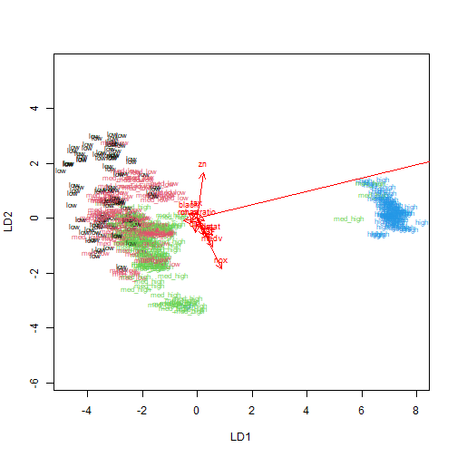

```r
# the function for lda biplot arrows
lda.arrows <- function(x, myscale = 1, arrow_heads = 0.1, color = "red", tex = 0.75, choices = c(1,2)){
  heads <- coef(x)
  arrows(x0 = 0, y0 = 0,
         x1 = myscale * heads[,choices[1]],
         y1 = myscale * heads[,choices[2]], col=color, length = arrow_heads)
  text(myscale * heads[,choices], labels = row.names(heads),
       cex = tex, col=color, pos=3)
}

# target classes as numeric
classes <- as.numeric(train$crime)

# plot the lda results
plot(lda.fit, dimen = 2, col = classes, pch = classes)
lda.arrows(lda.fit, myscale = 2.5)
```

## 6.

```r
# Save the crime categories from the test set and then remove the categorical crime variable from the test dataset. Then predict the classes with the LDA model on the test data. Cross tabulate the results with the crime categories from the test set. Comment on the results. (0-3 points)

# save the correct classes from test data
correct_classes <- test$crime

# remove the crime variable from test data
test <- dplyr::select(test, -crime)

# predict classes with test data
lda.pred <- predict(lda.fit, newdata = test)
```

```r
# cross tabulate the results
results <- table(correct = correct_classes, predicted = lda.pred$class)

# calculate model precision & sensitivity
table(correct = correct_classes, predicted = lda.pred$class)
```

```
##           predicted
## correct    low med_low med_high high
##   low       15       5        1    0
##   med_low    6      12        2    0
##   med_high   0      15       15    3
##   high       0       0        0   28
```

```r
1-diag(results)/colSums(results) # Precision: fraction of false positives
```

```
##        low    med_low   med_high       high
## 0.28571429 0.62500000 0.16666667 0.09677419
```

```r
1-diag(results)/rowSums(results) # Sensitivity: fraction of false negatives
```

```
##       low   med_low  med_high      high
## 0.2857143 0.4000000 0.5454545 0.0000000
```

## 7.

```r
# Make another scaled Boston data set
boston_scaled <- scale(Boston)

# Distances between observations
summary(dist(boston_scaled))
```

```
##    Min. 1st Qu.  Median    Mean 3rd Qu.    Max.
##  0.1343  3.4625  4.8241  4.9111  6.1863 14.3970
```

An ideal grouping has a minimal within-group sum of squares (“WGSS”) over all variables. Let’s plot these for one to ten-group solutions to see which solution has the smallest WGSS.

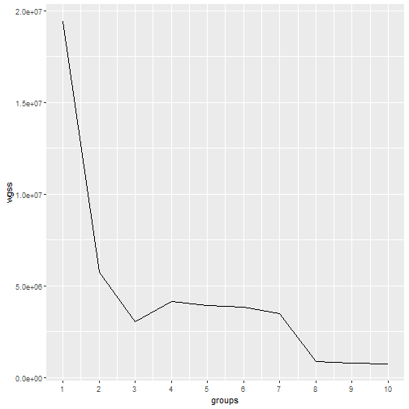

```r
set.seed(123)

# determine the number of clusters
k_max <- 10

# calculate the total within sum of squares
twcss <- sapply(1:k_max, function(k){kmeans(Boston, k)$tot.withinss})

# visualize the results
df<- data.frame(wgss=c(twcss),groups=1:k_max)
ggplot(data = df, aes(x=groups, y=wgss)) + geom_line() + scale_x_continuous(breaks = 1:10)
```

There are two “elbows” in the plot, at 3 and 8 groups. Let’s investigate those further.

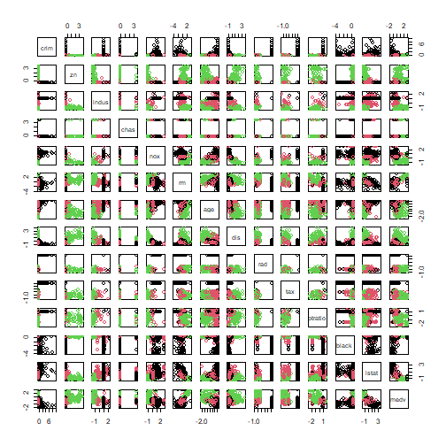

```r
set.seed(123)

# k-means clustering
km3 <- kmeans(boston_scaled, centers = 3)

# plot the Boston dataset with clusters
pairs(boston_scaled, col = km3$cluster)
```

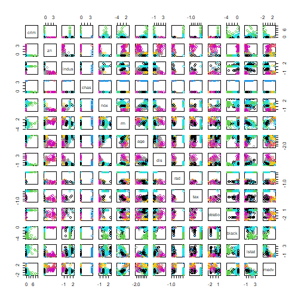

```r
# k-means clustering
km8 <- kmeans(boston_scaled, centers = 8)

# plot the Boston dataset with clusters
pairs(boston_scaled, col = km8$cluster)
```

It’s difficult to point out any single variable based on which the groups have been clustered (which is a good sign, I suppose). It’s likely that km3 makes a better model of the data as groups 4-7 actually make the model worse; km8 might just overfit the data by dividing groups into unnecessary subgroups.

# Dimensionality reduction techniques

```r
date()
```

```
## [1] "Tue Dec 13 02:32:54 2022"
```

```r
library(GGally)
library(dplyr)
#library(MASS)
library(tidyr)
library(corrplot)
library(ggplot2)
library(FactoMineR)

human <- read.table("https://raw.githubusercontent.com/KimmoVehkalahti/Helsinki-Open-Data-Science/master/datasets/human2.txt", sep =",", header = TRUE)
```

## 1.

```r
# Note: the variables and data set are described in create_human.R

summary(human)
```

```
##     Edu2.FM          Labo.FM          Edu.Exp         Life.Exp          GNI
##  Min.   :0.1717   Min.   :0.1857   Min.   : 5.40   Min.   :49.00   Min.   :   581
##  1st Qu.:0.7264   1st Qu.:0.5984   1st Qu.:11.25   1st Qu.:66.30   1st Qu.:  4198
##  Median :0.9375   Median :0.7535   Median :13.50   Median :74.20   Median : 12040
##  Mean   :0.8529   Mean   :0.7074   Mean   :13.18   Mean   :71.65   Mean   : 17628
##  3rd Qu.:0.9968   3rd Qu.:0.8535   3rd Qu.:15.20   3rd Qu.:77.25   3rd Qu.: 24512
##  Max.   :1.4967   Max.   :1.0380   Max.   :20.20   Max.   :83.50   Max.   :123124
##     Mat.Mor         Ado.Birth         Parli.F
##  Min.   :   1.0   Min.   :  0.60   Min.   : 0.00
##  1st Qu.:  11.5   1st Qu.: 12.65   1st Qu.:12.40
##  Median :  49.0   Median : 33.60   Median :19.30
##  Mean   : 149.1   Mean   : 47.16   Mean   :20.91
##  3rd Qu.: 190.0   3rd Qu.: 71.95   3rd Qu.:27.95
##  Max.   :1100.0   Max.   :204.80   Max.   :57.50
```

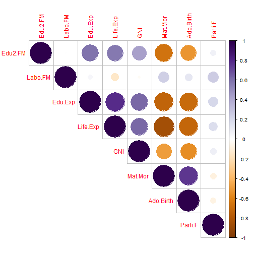

```r
corhum <- cor(human)
corrplot(corhum, type="upper", col=COL2(diverging="PuOr"))
```

```r
#human_scaled <- scale(human)
```

Life expectancy and maternal mortality make the strongest negative correlation, which is not surprising because an early maternal death brings life expectancy down. Adolescent birth rate and maternal mortality are, likewise, strongly correlated. Expected years of schooling strongly correlates with life expectancy. While strong, the correlation between share of population with at least secondary education and expected years of education is not among the highest. Perhaps education caps at some stage.

[output not shown]

[output cut: 9 more lines]

[output not shown]

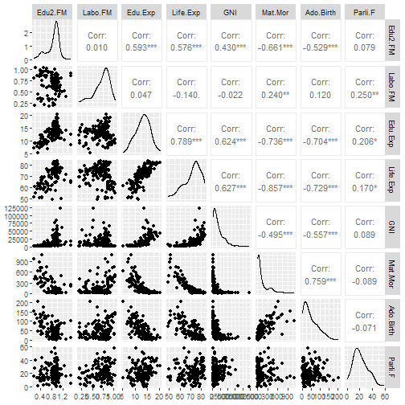

```r
ggpairs(human)
```

Looking at the distributions, only expected education looks “normally” distributed. As can also be seen from the summary, it is most common for most of the population to have a secondary education in the majority of countries. The most striking differences in variation can be seen in gross national income, maternal mortality and adolescent birth rate (where countries with a high gni are likely to have low maternal mortality).

## 2.

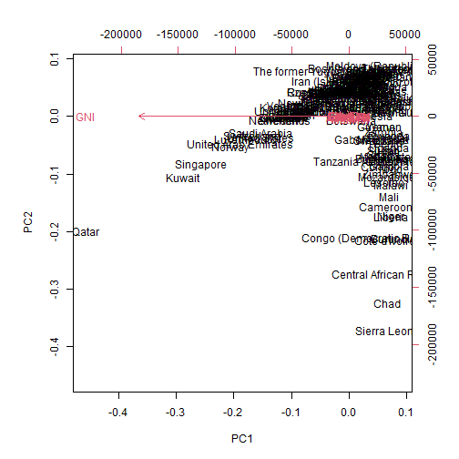

```r
pca_human <- prcomp(human)

biplot(pca_human)
```

## 3. & 4.

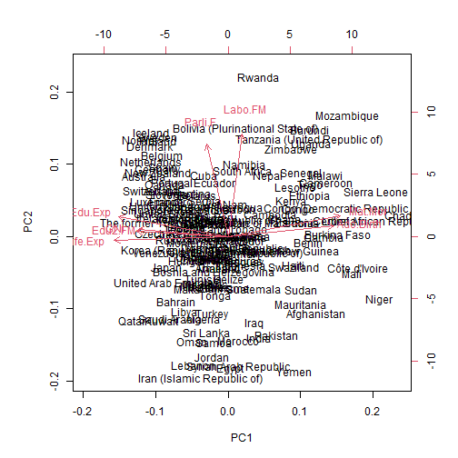

Scaling allows meaningful comparison between variables; as the numerical value of GNI was so large, it was likely to take over the whole model. The results look very different between scaled and non-scaled PCA. It is hard to make sense of the non-scaled PCA because of overlapping text.

In the scaled model, PC1 includes two sets of variables on opposite sides of the x axis. As mentioned before, maternal mortality and adolescent birth rates are intercorrelated, and countries with high GNI and life expectancy have low maternal mortality and birth rates.

The two components are rather orthogonal. This means that they are independent of one another. PC2 includes labour market participation rate and female shares of parliamentary seats. Both countries with high GNI, etc. and countries with higher maternal mortality etc. may have high or low shares of parliamentary seats for women or working population.

## 5.

```r
tea_time <- read.csv("https://raw.githubusercontent.com/KimmoVehkalahti/Helsinki-Open-Data-Science/master/datasets/tea_time.csv", stringsAsFactors = TRUE)

View(tea_time)
```

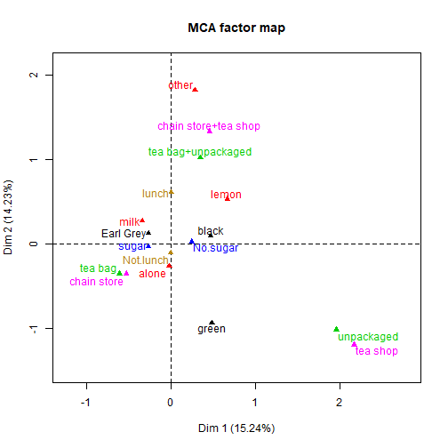

```r
mca <- MCA(tea_time, graph = FALSE)
plot(mca, invisible=c("ind"), graph.type = "classic", habillage="quali")
```

The closer the points are, the more similar their profiles are. For instance, Earl Grey, sugar and milk seem to go well together; tea bags are bought at chain stores; unpackaged tea is bought at tea shops.

# Analysis of longitudinal data

```r
library(GGally)
library(dplyr)
#library(MASS)
library(tidyr)
library(corrplot)
library(ggplot2)
#library(FactoMineR)
library(lme4)
```

## Part 1

```r
# Chapter 8 analyses
# Using RATS data
# Plot values for all rats

str(rats)
```

```
## 'data.frame':	16 obs. of  13 variables:
##  $ ID   : Factor w/ 16 levels "1","2","3","4",..: 1 2 3 4 5 6 7 8 9 10 ...
##  $ Group: Factor w/ 3 levels "1","2","3": 1 1 1 1 1 1 1 1 2 2 ...
##  $ WD1  : int  240 225 245 260 255 260 275 245 410 405 ...
##  $ WD8  : int  250 230 250 255 260 265 275 255 415 420 ...
##  $ WD15 : int  255 230 250 255 255 270 260 260 425 430 ...
##  $ WD22 : int  260 232 255 265 270 275 270 268 428 440 ...
##  $ WD29 : int  262 240 262 265 270 275 273 270 438 448 ...
##  $ WD36 : int  258 240 265 268 273 277 274 265 443 460 ...
##  $ WD43 : int  266 243 267 270 274 278 276 265 442 458 ...
##  $ WD44 : int  266 244 267 272 273 278 271 267 446 464 ...
##  $ WD50 : int  265 238 264 274 276 284 282 273 456 475 ...
##  $ WD57 : int  272 247 268 273 278 279 281 274 468 484 ...
##  $ WD64 : int  278 245 269 275 280 281 284 278 478 496 ...
```

```r
str(ratsl)
```

```
## tibble [176 × 5] (S3: tbl_df/tbl/data.frame)
##  $ ID    : Factor w/ 16 levels "1","2","3","4",..: 1 2 3 4 5 6 7 8 9 10 ...
##  $ Group : Factor w/ 3 levels "1","2","3": 1 1 1 1 1 1 1 1 2 2 ...
##  $ Time  : int [1:176] 1 1 1 1 1 1 1 1 1 1 ...
##  $ Weight: int [1:176] 240 225 245 260 255 260 275 245 410 405 ...
##  $ stdw  : num [1:176] -1.001 -1.12 -0.961 -0.842 -0.882 ...
```

```r
summary(rats)
```

```
##        ID     Group      WD1             WD8             WD15            WD22
##  1      : 1   1:8   Min.   :225.0   Min.   :230.0   Min.   :230.0   Min.   :232.0
##  2      : 1   2:4   1st Qu.:252.5   1st Qu.:255.0   1st Qu.:255.0   1st Qu.:267.2
##  3      : 1   3:4   Median :340.0   Median :345.0   Median :347.5   Median :351.5
##  4      : 1         Mean   :365.9   Mean   :369.1   Mean   :372.5   Mean   :379.2
##  5      : 1         3rd Qu.:480.0   3rd Qu.:476.2   3rd Qu.:486.2   3rd Qu.:492.5
##  6      : 1         Max.   :555.0   Max.   :560.0   Max.   :565.0   Max.   :580.0
##  (Other):10
##       WD29            WD36            WD43            WD44            WD50            WD57
##  Min.   :240.0   Min.   :240.0   Min.   :243.0   Min.   :244.0   Min.   :238.0   Min.   :247.0
##  1st Qu.:268.8   1st Qu.:267.2   1st Qu.:269.2   1st Qu.:270.0   1st Qu.:273.8   1st Qu.:273.8
##  Median :356.5   Median :360.0   Median :360.0   Median :362.0   Median :370.0   Median :373.5
##  Mean   :383.9   Mean   :387.0   Mean   :386.0   Mean   :388.3   Mean   :394.6   Mean   :398.6
##  3rd Qu.:497.8   3rd Qu.:504.2   3rd Qu.:501.0   3rd Qu.:510.5   3rd Qu.:516.0   3rd Qu.:524.5
##  Max.   :590.0   Max.   :597.0   Max.   :595.0   Max.   :595.0   Max.   :612.0   Max.   :618.0
##
##       WD64
##  Min.   :245.0
##  1st Qu.:278.0
##  Median :378.0
##  Mean   :404.1
##  3rd Qu.:530.8
##  Max.   :628.0
##
```

- The structure seems OK: ID is a factor with 16 levels (so there are 16 rats); group is a factor with 3 levels (so there are 3 manipulation groups in the study).
- Data in the wide form gives us an idea of the means of weekly weights of all rats.

Let’s plot individuals on the plot.

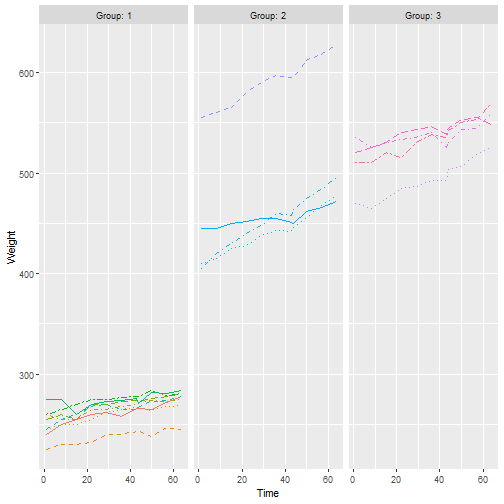

```r
ggplot(ratsl, aes(x = Time, y = Weight, col = ID, linetype = ID)) +
  geom_line() +
  scale_linetype_manual(values = rep(1:10, times=4)) +
  facet_grid(. ~ Group, labeller = label_both) +
  theme(legend.position = "none") +
  scale_y_continuous(limits = c(min(ratsl$Weight), max(ratsl$Weight)))
```

The rats start at very different weights: group 1 seems to have the lightest rats, for instance. Also, there’s one particularly chonky rat in Group 2. Let’s look at the data again after standardizing it.

```r
ratsl <- ratsl %>%
  group_by(Time) %>%
  mutate(stdw = (Weight-mean(Weight))/sd(Weight)) %>%
  ungroup()

# Glimpse the data
glimpse(ratsl)
```

```
## Rows: 176
## Columns: 5
## $ ID     <fct> 1, 2, 3, 4, 5, 6, 7, 8, 9, 10, 11, 12, 13, 14, 15, 16, 1, 2, 3, 4, 5, 6, 7, 8, 9, …
## $ Group  <fct> 1, 1, 1, 1, 1, 1, 1, 1, 2, 2, 2, 2, 3, 3, 3, 3, 1, 1, 1, 1, 1, 1, 1, 1, 2, 2, 2, 2…
## $ Time   <int> 1, 1, 1, 1, 1, 1, 1, 1, 1, 1, 1, 1, 1, 1, 1, 1, 15, 15, 15, 15, 15, 15, 15, 15, 15…
## $ Weight <int> 240, 225, 245, 260, 255, 260, 275, 245, 410, 405, 445, 555, 470, 535, 520, 510, 25…
## $ stdw   <dbl> -1.0011429, -1.1203857, -0.9613953, -0.8421525, -0.8819001, -0.8421525, -0.7229096…
```

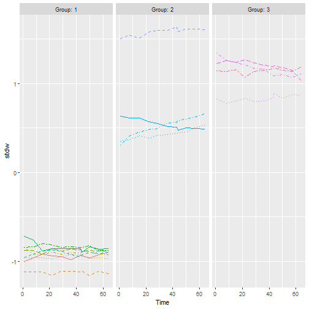

```r
# Plot again with the standardised bprs
ggplot(ratsl, aes(x = Time, y = stdw, col = ID, linetype = ID)) +
  geom_line() +
  scale_linetype_manual(values = rep(1:10, times=4)) +
  facet_grid(. ~ Group, labeller = label_both) +
  theme(legend.position = "none") +
  scale_y_continuous(limits = c(min(ratsl$stdw), max(ratsl$stdw)))
```

Let’s plot summary graphs for each group, also visualizing standard error of the mean.

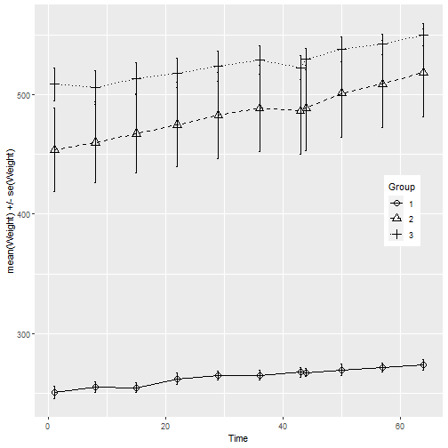

From this graph, we can see that group two seems to have a very large standard error – likely due to the chonky outlier.